# Modeling 3 Tutorial

Mario Giacomazzo

March 17, 2019

# Introduction

Today, we will work with daily water temperature and air temperature data observed for 31 rivers in Spain. The goal of this tutorial is to identify the best model for predicting the maximum water temperature given the maximum air temperature. In the preview below, `W` represents the daily maximum water temperature and `A` represents the daily maximum air temperature. The data contains almost a full year of data for each of the 31 different rivers.

```
## # A tibble: 6 x 8
##   JULIAN_DAY  YEAR     L     W     A  TIME MONTH   DAY
##        <int> <int> <int> <dbl> <dbl> <int> <int> <int>
## 1          1  2003   103  14.2  21.2     1     1     1
## 2          2  2003   103  14.4  16.8     2     1     2
## 3          3  2003   103  14.4  15.4     3     1     3
## 4          4  2003   103  10.9  10.8     4     1     4
## 5          5  2003   103  10.8  11.7     5     1     5
## 6          6  2003   103  10.7  12.4     6     1     6
```

# Part 1: Examining the Relationship

## Chunk 1: Overall Relationship

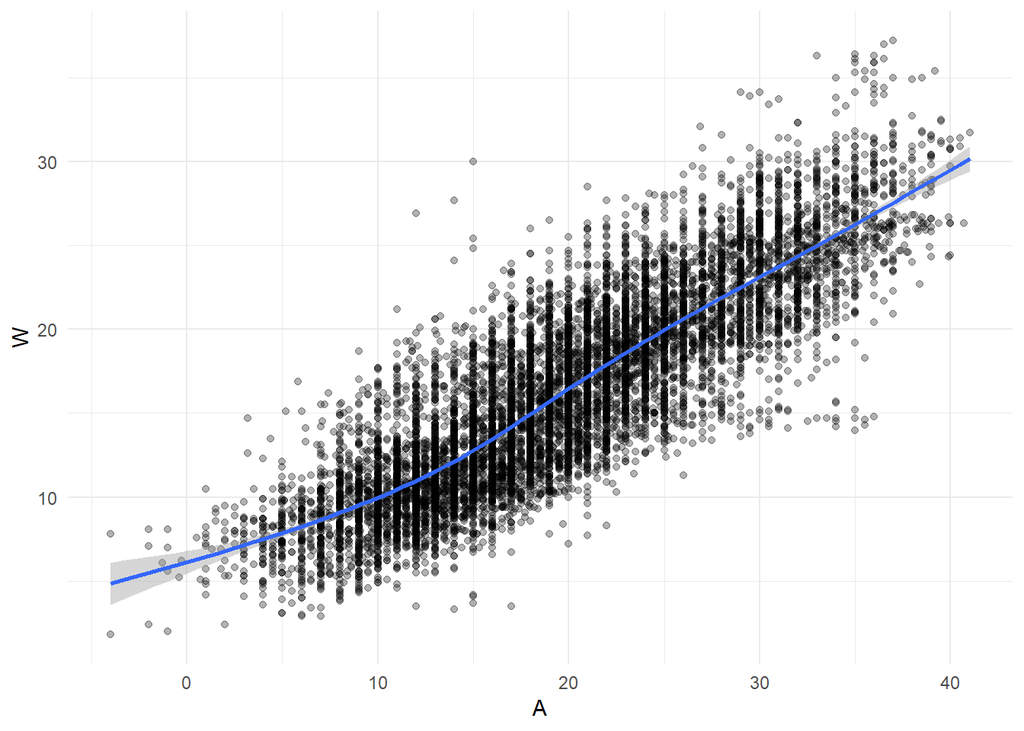

## Chunk 2: Location-Specific Relationship

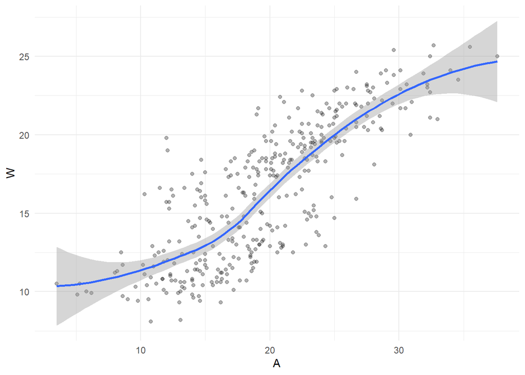

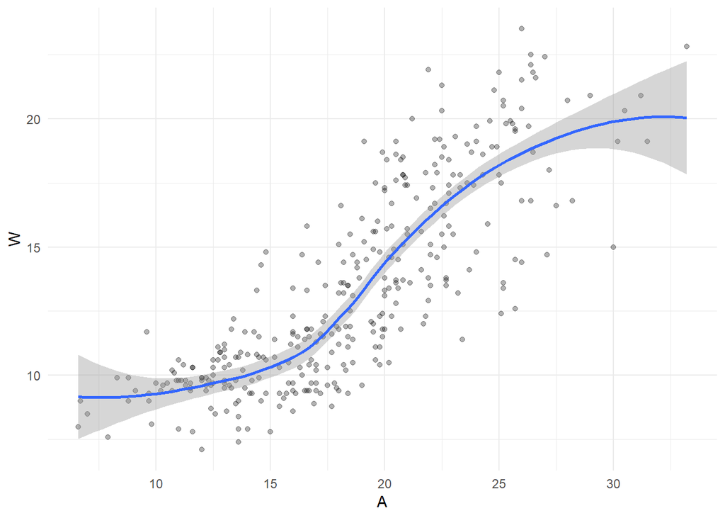

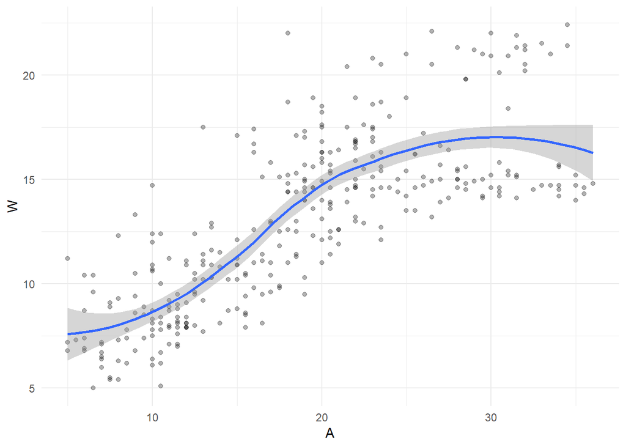

## Chunk 3: Split Data into Train and Test Sets

```r
set.seed(216)
TEST.LOCATIONS=sample(x=unique(DATA$L),size=3,replace=F)

TRAIN = anti_join(DATA,tibble(L=TEST.LOCATIONS),by="L")
TEST = semi_join(DATA,tibble(L=TEST.LOCATIONS),by="L")
```

## Chunk 4: Plots of Relationship for Train and Test Data

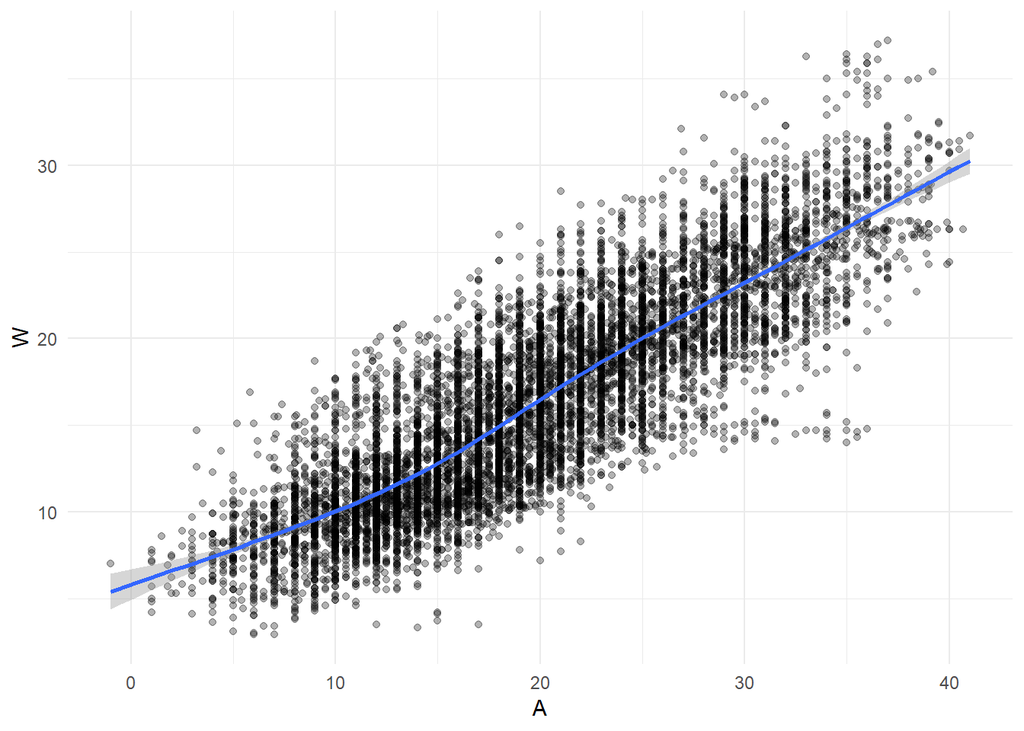

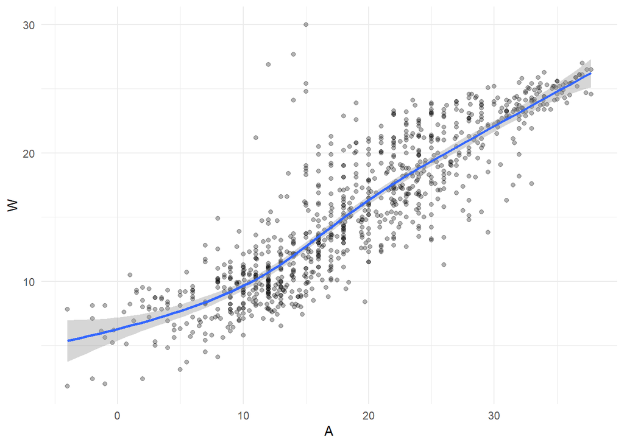

# Part 2: Linear Regression Model

## Chunk 1: Fitting Linear Model to Train Data

```
##
## Call:
## lm(formula = W ~ A, data = TRAIN)
##
## Residuals:
##      Min       1Q   Median       3Q      Max
## -12.4202  -2.1818  -0.1244   1.9703  11.6590
##
## Coefficients:
##             Estimate Std. Error t value            Pr(>|t|)
## (Intercept) 3.349124   0.089745   37.32 <0.0000000000000002 ***
## A           0.658341   0.004233  155.51 <0.0000000000000002 ***
## ---
## Signif. codes:  0 '***' 0.001 '**' 0.01 '*' 0.05 '.' 0.1 ' ' 1
##
## Residual standard error: 3.127 on 8917 degrees of freedom
##   (1322 observations deleted due to missingness)
## Multiple R-squared:  0.7306, Adjusted R-squared:  0.7306
## F-statistic: 2.418e+04 on 1 and 8917 DF,  p-value: < 0.00000000000000022
```

## Chunk 2: Getting Predictions from Linear Model

```r
TRAIN2 = TRAIN %>% add_predictions(linmod,var="linpred")
TEST2 = TEST %>% add_predictions(linmod,var="linpred")
```

## Chunk 3: Getting Residuals from Linear Model

```r
TRAIN3 = TRAIN2 %>% add_residuals(linmod,var="linres")
TEST3 = TEST2 %>% add_residuals(linmod,var="linres")
```

# Part 3: Polynomial Regression Model

## Chunk 1: Fitting Polynomial Regression Models

```r
poly2mod=lm(W~A+I(A^2),data=TRAIN)
poly3mod=lm(W~A+I(A^2)+I(A^3),data=TRAIN)
poly4mod=lm(W~A+I(A^2)+I(A^3)+I(A^4),data=TRAIN)
anova(linmod,poly2mod,poly3mod,poly4mod,test="Chisq")
```

```
## Analysis of Variance Table
##
## Model 1: W ~ A
## Model 2: W ~ A + I(A^2)
## Model 3: W ~ A + I(A^2) + I(A^3)
## Model 4: W ~ A + I(A^2) + I(A^3) + I(A^4)
##   Res.Df   RSS Df Sum of Sq              Pr(>Chi)
## 1   8917 87171
## 2   8916 86900  1    270.50 0.0000001229519902145 ***
## 3   8915 86257  1    642.91 0.0000000000000003521 ***
## 4   8914 86194  1     63.09               0.01064 *
## ---
## Signif. codes:  0 '***' 0.001 '**' 0.01 '*' 0.05 '.' 0.1 ' ' 1
```

## Chunk 2: Getting Predictions from Polynomial Models

```r
TRAIN4 =TRAIN3 %>%
  add_predictions(poly2mod,var="poly2pred") %>%
  add_predictions(poly3mod,var="poly3pred") %>%
  add_predictions(poly4mod,var="poly4pred")

TEST4 =TEST3 %>%
  add_predictions(poly2mod,var="poly2pred") %>%
  add_predictions(poly3mod,var="poly3pred") %>%
  add_predictions(poly4mod,var="poly4pred")
```

## Chunk 3: Getting Residuals from Polynomial Models

```r
TRAIN5 =TRAIN4 %>%
  add_residuals(poly2mod,var="poly2res") %>%
  add_residuals(poly3mod,var="poly3res") %>%
  add_residuals(poly4mod,var="poly4res")

TEST5 =TEST4 %>%
  add_residuals(poly2mod,var="poly2res") %>%
  add_residuals(poly3mod,var="poly3res") %>%
  add_residuals(poly4mod,var="poly4res")
```

# Part 4: Nonlinear Logistic Model

## Chunk 1: Logistic Model Investigation

## Chunk 2: Essential Functions for Nonlinear Logistic Model

```r
logistic.model=function(COEF,DATA){
  pred=COEF[1]+COEF[2]/(1+exp(COEF[3]-COEF[4]*DATA$A))
}
MSE.logistic=function(COEF,DATA){
  error=DATA$W-logistic.model(DATA=DATA,COEF=COEF)
  sq.error=error^2
  mse=mean(sq.error,na.rm=T)
  return(mse)
}
```

## Chunk 3: Estimate Parameters for Nonlinear Logistic Model

```r
logistic.mod=optim(
  par=c(min(TRAIN$W,na.rm=T),
        max(TRAIN$W,na.rm=T)-min(TRAIN$W,na.rm=T),
        median(TRAIN$A,na.rm=T),
        1),           #Smart Starting Values
  fn=MSE.logistic,    #Function to Minimize
  DATA=TRAIN          #Required Argument
)
print(logistic.mod)
```

[output not shown]

## Chunk 4: Obtain Predictions and Residuals

```r
TRAIN6=TRAIN5 %>% mutate(logpred=logistic.model(COEF=logistic.mod$par,DATA=TRAIN5),
                         logres=W-logpred)
TEST6=TEST5 %>% mutate(logpred=logistic.model(COEF=logistic.mod$par,DATA=TEST5),
                         logres=W-logpred)
```

# Intermission:

The function `save.image()` in R can be used to save all objects in the global environment. This is very helpful when you want work off your results without rerunning all previous R code. The name of the exported information should contain the file extension *.Rdata*. These files can be extremely large depending how much RAM was utilized in your R session. The function `load()` can be used to import a previous workspace.

For more information on *.Rdata* file types, see https://fileinfo.com/extension/rdata for help.

```r
save.image("Tutorial12.Rdata")
```

# Part 5: Evaluation by Visualization

## Chunk 1: Plotting Models

## Chunk 2: Predicted Versus Actual Max Water Temperature

## Chunk 3: Plotting Residuals Versus Time

## Chunk 4: Evaluating The Location-Specific Error

# Part 6: Evaluation by Numerical Summary

## Chunk 1: Functions Required For Evaluating Prediction

```r
bias.func=function(res){
  bias=mean(res,na.rm=T)
  return(bias)
}

mae.func=function(res){
  mae=mean(abs(res),na.rm=T)
  return(mae)
}

rmse.func=function(res){
  mse=mean(res^2,na.rm=T)
  rmse=sqrt(mse)
  return(rmse)
}
```

## Chunk 2: Checking Functions

```r
ex.res=TEST6$linres
c(bias.func(ex.res),mae.func(ex.res),rmse.func(ex.res))

ex.res.mat=TEST6 %>% select(linres,poly2res,poly3res,poly4res,logres)
apply(ex.res.mat,2,bias.func)
apply(ex.res.mat,2,mae.func)
apply(ex.res.mat,2,rmse.func)
```

[output not shown]

## Chunk 3: Get Table Quickly

## Chunk 4: HTML Formatted Table